# Heart Failure analysis and modeling - code and outputs

Alexander Kheirallah

07/10/2020

This HTML/PDF file is accompanied by explanatory `README` as well as `report.pdf` both hosted on [this](https://github.com/msxakk89/heart_failure) repository. Below you can find the *code* and *comment* sections. In the *comment* section I elaborate in more detail about the analysis and choice of specific approaches.

# Code section

## Data processing

### Data formatting and value modifications

```r
d = read.table(here("data","processed.cleveland.data"),sep = ",",stringsAsFactors = F)
features = c("age","sex","cp","trestbps","chol","fbs","restecg","thalach","exang","oldpeak","slope","ca","thal")
names(d) = c(features,"Y")
d$ca = as.numeric(d$ca)
d$thal = as.numeric(d$thal)
d$slope[d$slope==3]=1
d$slope[d$slope==1]=3
d$thal[d$thal==3]=1
d$thal[d$thal==7]=2
d$thal[d$thal==6]=3
d$cp = as.factor(d$cp)
d$restecg = as.factor(d$restecg)
```

### Checking what variables have missing data

```r
colSums(is.na(d))
```

```
##      age      sex       cp trestbps     chol      fbs  restecg  thalach
##        0        0        0        0        0        0        0        0
##    exang  oldpeak    slope       ca     thal        Y
##        0        0        0        4        2        0
```

### Removing rows with at least one NA and checking the size of resulting table

```r
keep = !(is.na(d$ca) | is.na(d$thal))
d = d[keep,]
dim(d)
```

```
## [1] 297  14
```

### Converting outcome to a binary label and checking relative proportions of diseased and healthy individuals

```r
d = d %>%
  mutate(Y=Y>0)
table(d$Y)
```

```
##
## FALSE  TRUE
##   160   137
```

## Plotting data distributions

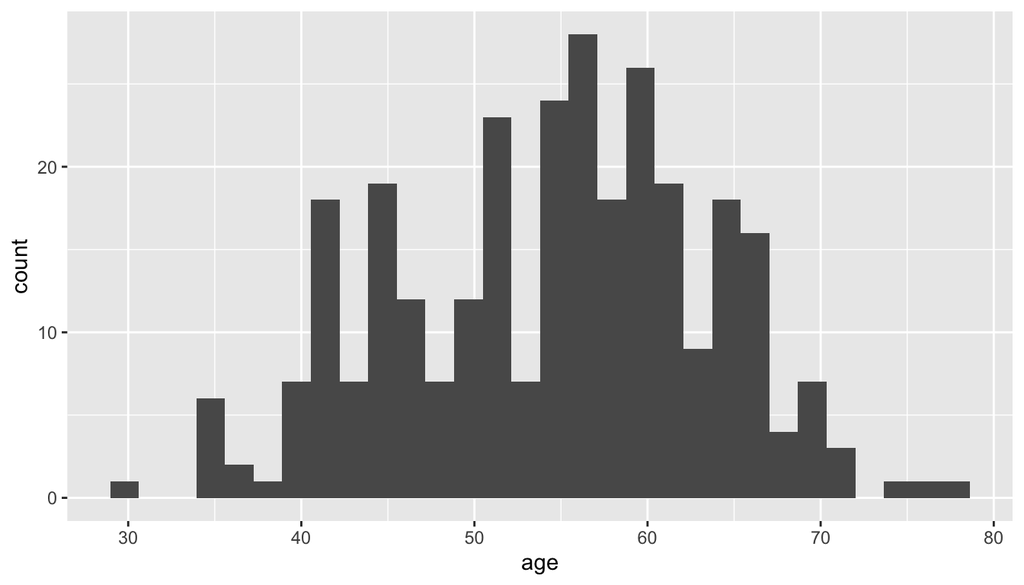

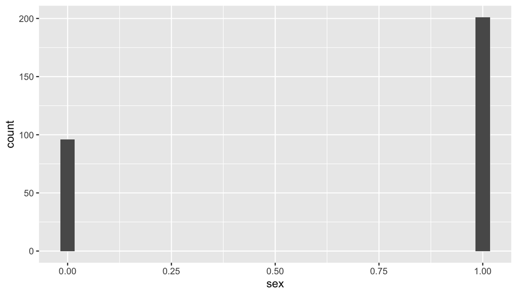

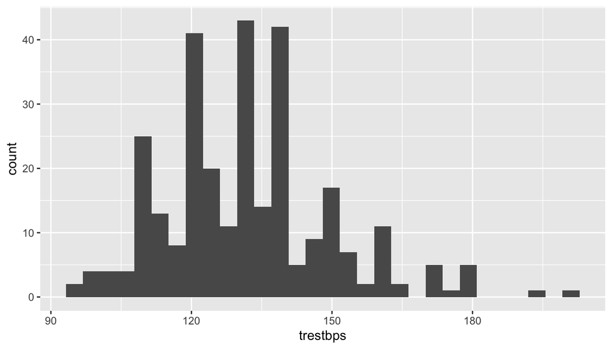

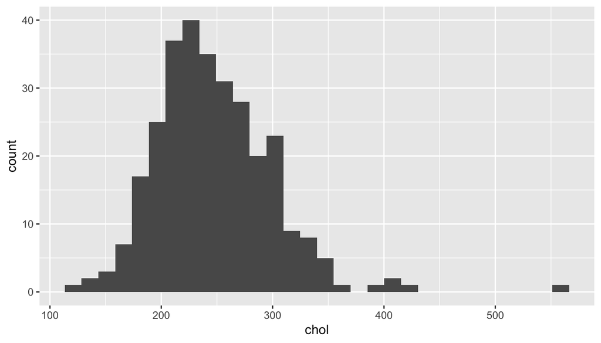

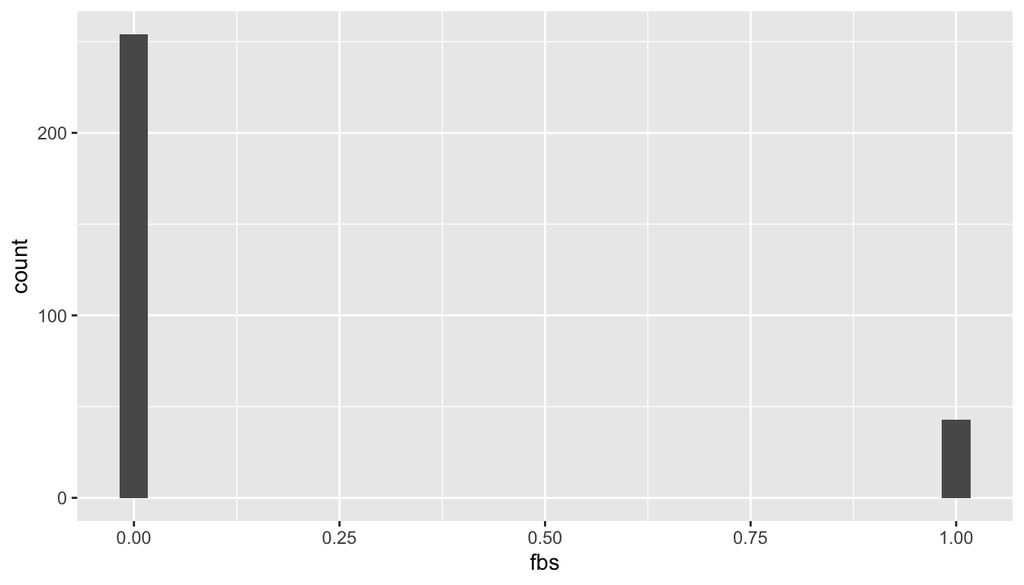

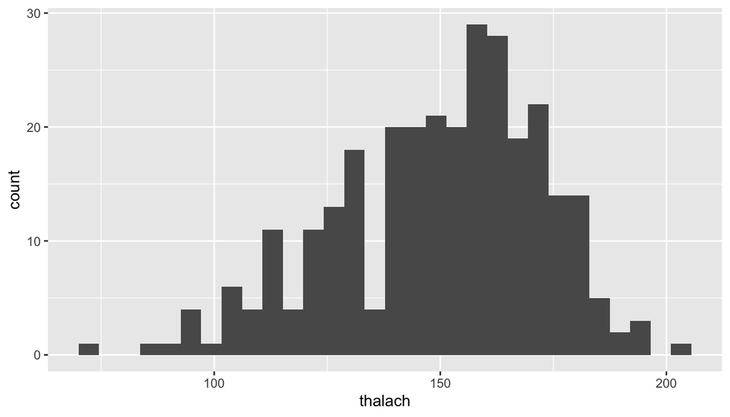

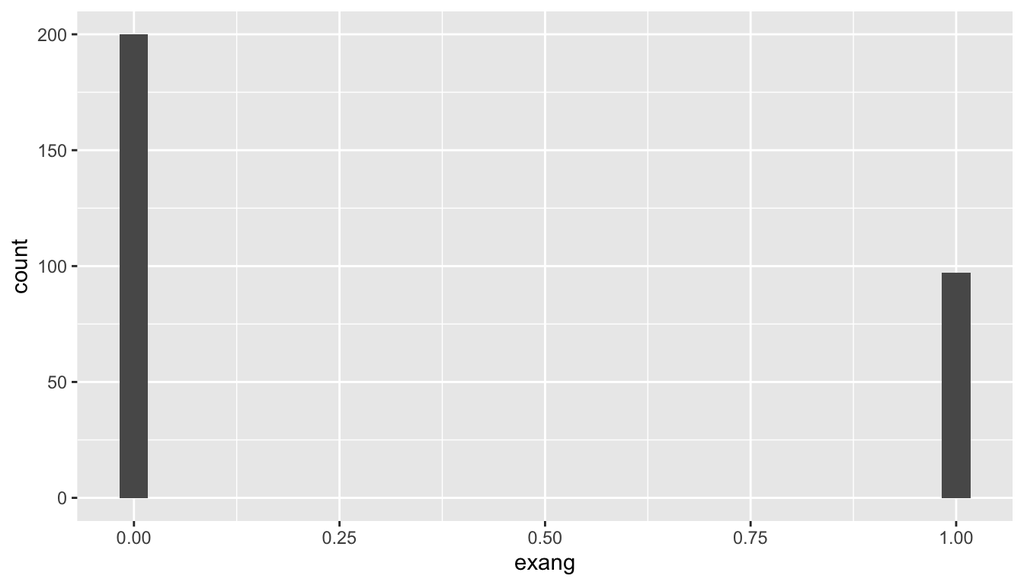

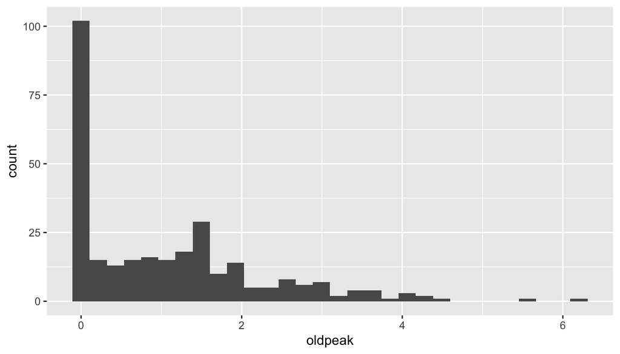

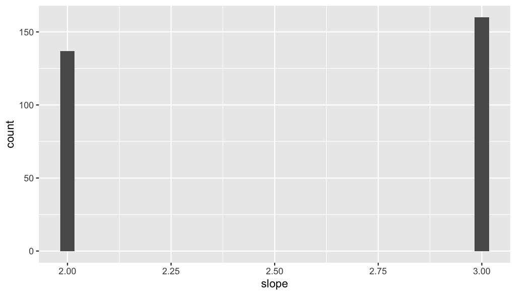

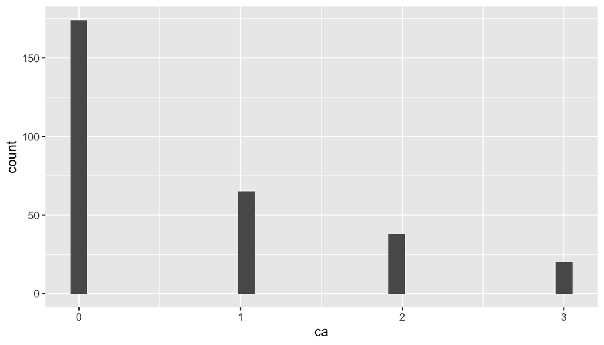

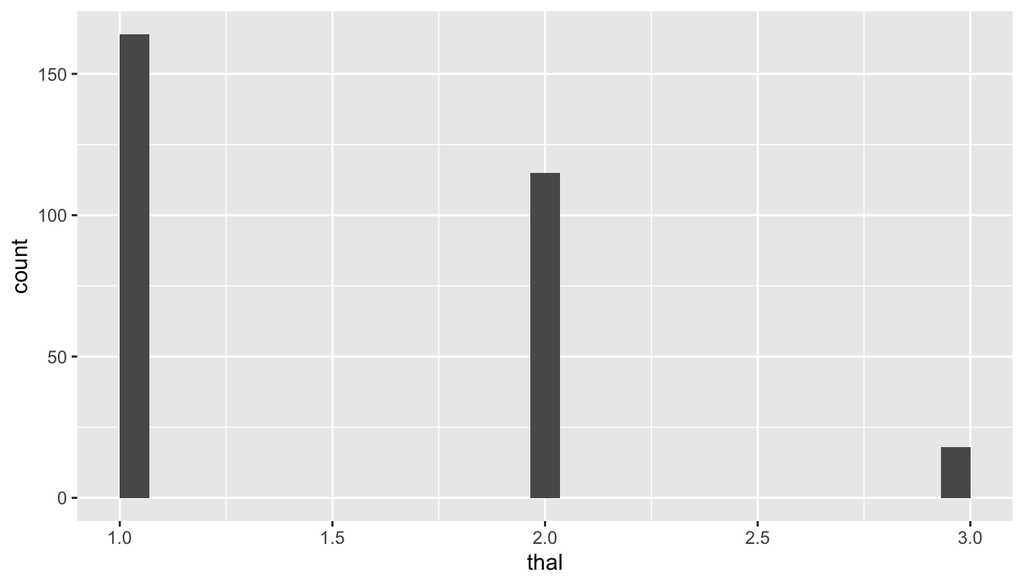

```r
for(f in features[-match(c("cp","restecg"),features)]){
  print(d %>%
    ggplot(aes_string(x = f)) +geom_histogram())
}
```

## Calculating feature importance

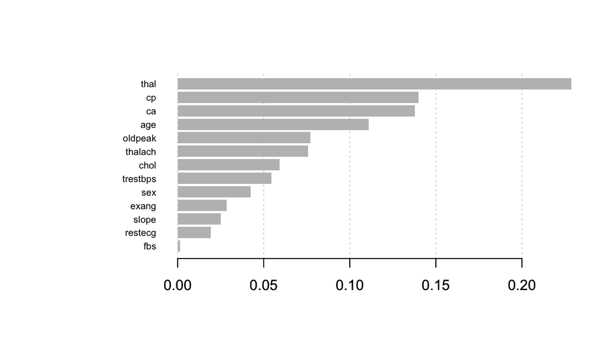

```r
X = d[,features]
Y = d[,"Y"]
parameters = list(booster = "gbtree",
                  objective = "binary:logistic")

xgb = xgboost(data = data.matrix(X),
              label = Y,
              nrounds = 1000,
              verbose = F,
              params = parameters)

importance_matrix = xgb.importance(model = xgb,feature_names = features)
xgb.plot.importance(importance_matrix[1:nrow(importance_matrix),])
```

## Undertaking the iterative model evaluation procedure with plotting of AUC values for both train and test partitions

```r
allFeatures_ordered = importance_matrix$Feature

splits = train_test_split(d = d,train_size = 0.6,seed = 123)
train = splits$train
test = splits$test

act_train = train$Y
act_test = test$Y

RUCs_train = c()
RUCs_test = c()

x = allFeatures_ordered[1]
form = paste("Y ~",x)
fit = glm(form, data = train, family = "binomial")

train_pred = predict(fit,newdata = train,type = "response")
roc_train = roc(response = act_train,predictor = train_pred,plot=F)
RUCs_train = c(RUCs_train,roc_train$auc)

test_pred = predict(fit,newdata = test,type = "response")
roc_test = roc(response = act_test,predictor = test_pred,plot=F)
RUCs_test = c(RUCs_test,roc_test$auc)

for (i in 2:length(allFeatures_ordered)) {
  f = allFeatures_ordered[i]
  # update feature space
  x = paste(x,"+",f)
  form = paste("Y ~",x)
  fit = glm(form, data = train, family = "binomial")

  train_pred = predict(fit,newdata = train,type = "response")
  roc_train = roc(response = act_train,predictor = train_pred,plot=F)
  RUCs_train = c(RUCs_train,roc_train$auc)

  test_pred = predict(fit,newdata = test,type = "response")
  roc_test = roc(response = act_test,predictor = test_pred,plot=F)
  RUCs_test = c(RUCs_test,roc_test$auc)
}
```

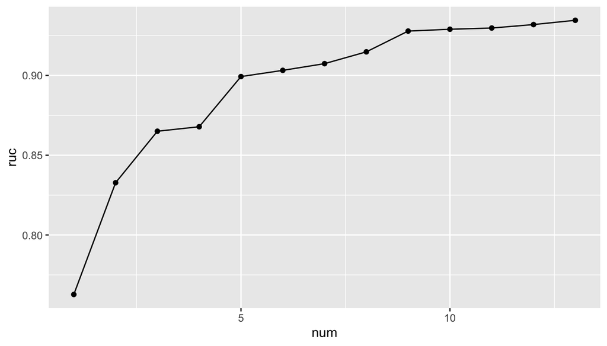

```r
RUCs_train_d = as.data.frame(cbind(num=1:length(RUCs_train),ruc=RUCs_train))
ggplot(RUCs_train_d, aes(x=num, y=ruc)) + geom_point() + geom_line()
```

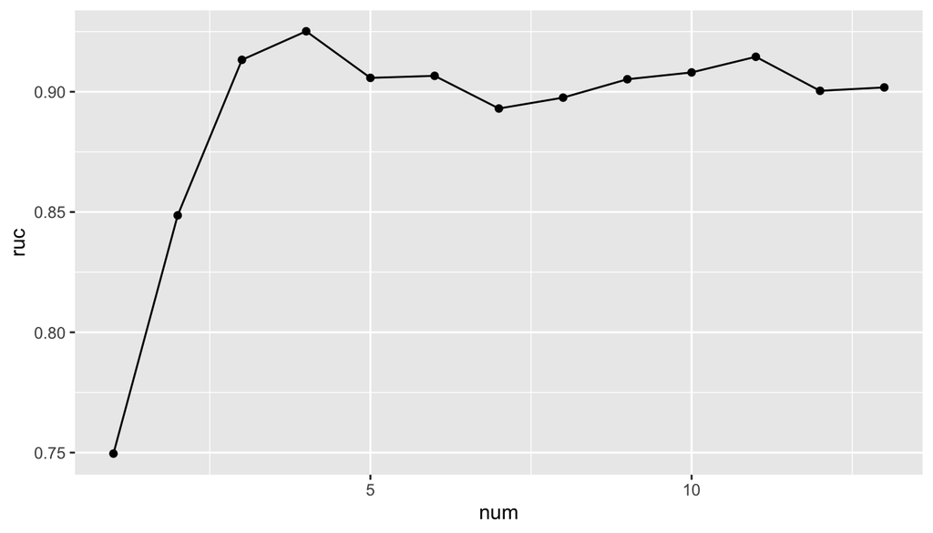

```r
RUCs_test_d = as.data.frame(cbind(num=1:length(RUCs_test),ruc=RUCs_test))
ggplot(RUCs_test_d, aes(x=num, y=ruc)) + geom_point() + geom_line()
```

## Plotting the ROC curve with 4 most important features included

### With seed 123 (same as in model evaluation procedure)

```r
fit = glm(Y ~ thal + cp + ca + age, data = train, family = "binomial")
train_pred = predict(fit,newdata = train,type = "response")
test_pred = predict(fit,newdata = test,type = "response")

par(pty="s")
# train
roc(response = act_train,predictor = train_pred,
    plot=T, legacy.axes=T, percent=T, xlab = "False Positive %", ylab = "True Positive %", col="blue",print.auc=T)
```

```
##
## Call:
## roc.default(response = act_train, predictor = train_pred, percent = T,     plot = T, legacy.axes = T, xlab = "False Positive %", ylab = "True Positive %",     col = "blue", print.auc = T)
##
## Data: train_pred in 98 controls (act_train FALSE) < 80 cases (act_train TRUE).
## Area under the curve: 86.79%
```

```r
# test
roc(response = act_test,predictor = test_pred,
    percent=T, col="red", lwd=1, print.auc=T, add=T, print.auc.y=40, plot = T)
```

```
##
## Call:
## roc.default(response = act_test, predictor = test_pred, percent = T,     plot = T, col = "red", lwd = 1, print.auc = T, add = T, print.auc.y = 40)
##
## Data: test_pred in 62 controls (act_test FALSE) < 57 cases (act_test TRUE).
## Area under the curve: 92.52%
```

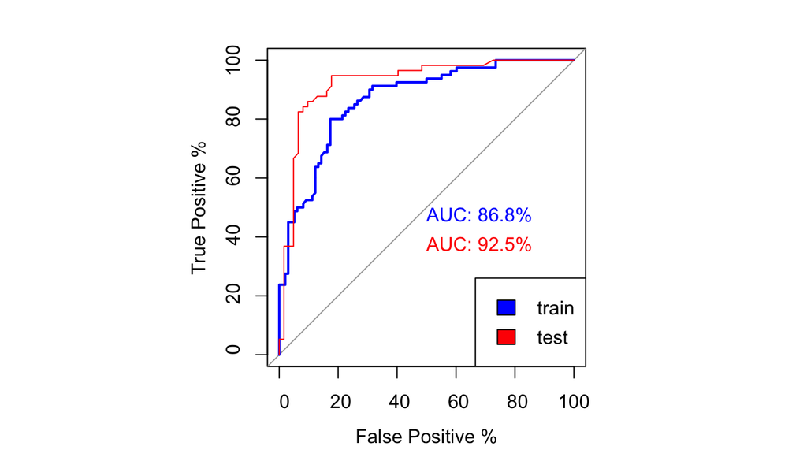

```r
legend("bottomright",c("train","test"),fill=c("blue","red"))
```

### With a new seed to test what happens with test’s AUC as a result of this change

```r
splits = train_test_split(d = d,train_size = 0.6,seed = 567)
train = splits$train
test = splits$test

act_train = train$Y
act_test = test$Y

fit = glm(Y ~ thal + cp + ca + age, data = train, family = "binomial")
train_pred = predict(fit,newdata = train,type = "response")
test_pred = predict(fit,newdata = test,type = "response")

par(pty="s")
# train
roc(response = act_train,predictor = train_pred,
    plot=T, legacy.axes=T, percent=T, xlab = "False Positive %", ylab = "True Positive %", col="blue",print.auc=T)
```

```
##
## Call:
## roc.default(response = act_train, predictor = train_pred, percent = T,     plot = T, legacy.axes = T, xlab = "False Positive %", ylab = "True Positive %",     col = "blue", print.auc = T)
##
## Data: train_pred in 99 controls (act_train FALSE) < 79 cases (act_train TRUE).
## Area under the curve: 91.5%
```

```r
# test
roc(response = act_test,predictor = test_pred,
    percent=T, col="red", lwd=1, print.auc=T, add=T, print.auc.y=40, plot = T)
```

```
##
## Call:
## roc.default(response = act_test, predictor = test_pred, percent = T,     plot = T, col = "red", lwd = 1, print.auc = T, add = T, print.auc.y = 40)
##
## Data: test_pred in 61 controls (act_test FALSE) < 58 cases (act_test TRUE).
## Area under the curve: 82.5%
```

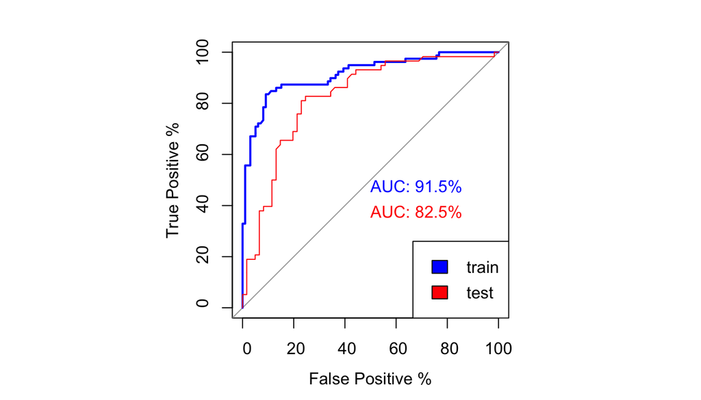

```r
legend("bottomright",c("train","test"),fill=c("blue","red"))
```